# Retail Data Analysis

Deo Ivan Mareza

1/16/2020

# 1 Brief Summary

Hello and welcome to my training R document. In this document, I will try to analyze a retail data of a company, and see what kind of conclusion and business insight we might have.

The main objective of this document is to practise and sharpen my R command, as well compare data and get some insights on the given data.

# 2 The Data

```r
# data set

retail <- read.csv(file="data_input/retail.csv")
```

This is the first look of the data that we received.

The only cleanup we need is to change some factors to characters, and removing some columns that we don’t need.

```r
head(retail)
```

```
##   Row.ID       Order.ID Order.Date Ship.Date      Ship.Mode Customer.ID
## 1      1 CA-2016-152156    11/8/16  11/11/16   Second Class    CG-12520
## 2      2 CA-2016-152156    11/8/16  11/11/16   Second Class    CG-12520
## 3      3 CA-2016-138688    6/12/16   6/16/16   Second Class    DV-13045
## 4      4 US-2015-108966   10/11/15  10/18/15 Standard Class    SO-20335
## 5      5 US-2015-108966   10/11/15  10/18/15 Standard Class    SO-20335
## 6      6 CA-2014-115812     6/9/14   6/14/14 Standard Class    BH-11710
##     Segment      Product.ID        Category Sub.Category
## 1  Consumer FUR-BO-10001798       Furniture    Bookcases
## 2  Consumer FUR-CH-10000454       Furniture       Chairs
## 3 Corporate OFF-LA-10000240 Office Supplies       Labels
## 4  Consumer FUR-TA-10000577       Furniture       Tables
## 5  Consumer OFF-ST-10000760 Office Supplies      Storage
## 6  Consumer FUR-FU-10001487       Furniture  Furnishings
##                                                       Product.Name    Sales
## 1                                Bush Somerset Collection Bookcase 261.9600
## 2      Hon Deluxe Fabric Upholstered Stacking Chairs, Rounded Back 731.9400
## 3        Self-Adhesive Address Labels for Typewriters by Universal  14.6200
## 4                    Bretford CR4500 Series Slim Rectangular Table 957.5775
## 5                                   Eldon Fold 'N Roll Cart System  22.3680
## 6 Eldon Expressions Wood and Plastic Desk Accessories, Cherry Wood  48.8600
##   Quantity Discount    Profit
## 1        2     0.00   41.9136
## 2        3     0.00  219.5820
## 3        2     0.00    6.8714
## 4        5     0.45 -383.0310
## 5        2     0.20    2.5164
## 6        7     0.00   14.1694
```

# 3 Data Cleanup

At this stage, there’s a few things that I’d like to do, which is : *1. Remove Row.ID, Order.ID, and Customer.ID* *2. Fix data type*

```r
# retail <- read.csv(file="data_input/retail.csv")


colnames(retail)
```

```
##  [1] "Row.ID"       "Order.ID"     "Order.Date"   "Ship.Date"    "Ship.Mode"
##  [6] "Customer.ID"  "Segment"      "Product.ID"   "Category"     "Sub.Category"
## [11] "Product.Name" "Sales"        "Quantity"     "Discount"     "Profit"
```

```r
retail <- retail[,-c(1,2,6)]
# retail <- retail[,-"Customer.ID"]
```

```r
retail$Order.Date <- as.Date(retail$Order.Date, "%m/%d/%y")
retail$Ship.Date <- as.Date(retail$Ship.Date, "%m/%d/%y")


retail$Product.ID <- as.character(retail$Product.ID)
retail$Product.Name <- as.factor(retail$Product.Name)


str(retail)
```

```
## 'data.frame':    9994 obs. of  12 variables:
##  $ Order.Date  : Date, format: "2016-11-08" "2016-11-08" ...
##  $ Ship.Date   : Date, format: "2016-11-11" "2016-11-11" ...
##  $ Ship.Mode   : Factor w/ 4 levels "First Class",..: 3 3 3 4 4 4 4 4 4 4 ...
##  $ Segment     : Factor w/ 3 levels "Consumer","Corporate",..: 1 1 2 1 1 1 1 1 1 1 ...
##  $ Product.ID  : chr  "FUR-BO-10001798" "FUR-CH-10000454" "OFF-LA-10000240" "FUR-TA-10000577" ...
##  $ Category    : Factor w/ 3 levels "Furniture","Office Supplies",..: 1 1 2 1 2 1 2 3 2 2 ...
##  $ Sub.Category: Factor w/ 17 levels "Accessories",..: 5 6 11 17 15 10 3 14 4 2 ...
##  $ Product.Name: Factor w/ 1850 levels "\"While you Were Out\" Message Book, One Form per Page",..: 387 833 1440 367 574 570 1137 1099 535 295 ...
##  $ Sales       : num  262 731.9 14.6 957.6 22.4 ...
##  $ Quantity    : int  2 3 2 5 2 7 4 6 3 5 ...
##  $ Discount    : num  0 0 0 0.45 0.2 0 0 0.2 0.2 0 ...
##  $ Profit      : num  41.91 219.58 6.87 -383.03 2.52 ...
```

Now that we have removed the columns we do not need as well as making sure all the data types are correct, we’re ready to begin the analysis.

# 4 Data Analysis

The data provided is a sales data within the period of 3rd January 2014 to 30th December 2017.

```r
min(retail$Order.Date)
```

```
## [1] "2014-01-03"
```

```r
max(retail$Order.Date)
```

```
## [1] "2017-12-30"
```

## 4.1 TOP 10

**Top 10 Products based on Quantity :**

```r
productSoldQty <- aggregate(formula = Quantity ~ Product.Name, data = retail, FUN = max)

productSoldQty[order(productSoldQty$Quantity, decreasing = T),][1:10,]
```

```
##                                                                          Product.Name
## 40          Acco 7-Outlet Masterpiece Power Center, Wihtout Fax/Phone Line Protection
## 140                             Anker Ultra-Slim Mini Bluetooth 3.0 Wireless Keyboard
## 179 Avery 4027 File Folder Labels for Dot Matrix Printers, 5000 Labels per Box, White
## 408                                                  Cardinal EasyOpen D-Ring Binders
## 499                                                           DAX Wood Document Frame
## 584             Eldon ProFile File 'N Store Portable File Tub Letter/Legal Size Black
## 594                               Electrix Architect's Clamp-On Swing Arm Lamp, Black
## 765                                        Global Push Button Manager's Chair, Indigo
## 767                                            Global Stack Chair without Arms, Black
## 806                                                 High-Back Leather Manager's Chair
##     Quantity
## 40        14
## 140       14
## 179       14
## 408       14
## 499       14
## 584       14
## 594       14
## 765       14
## 767       14
## 806       14
```

**Top 10 Most Profitable Product :**

Using aggregates to count the max profit

```r
agg1 <- aggregate(formula = Profit ~ Product.Name, data = retail, FUN = max )

agg1[order(agg1$Profit, decreasing=TRUE),][1:10,]
```

```
##                                                                    Product.Name
## 399                                       Canon imageCLASS 2200 Advanced Copier
## 689                            GBC Ibimaster 500 Manual ProClick Binding System
## 896                                        Ibico EPK-21 Electric Binding System
## 651 Fellowes PB500 Electric Punch Plastic Comb Binding Machine with Manual Bind
## 879                   HP Designjet T520 Inkjet Large Format Printer - 24" Color
## 805                                        Hewlett Packard LaserJet 3310 Copier
## 684                                   GBC DocuBind P400 Electric Binding System
## 166                                           Ativa V4110MDD Micro-Cut Shredder
## 20                             3D Systems Cube Printer, 2nd Generation, Magenta
## 403                                          Canon PC1060 Personal Laser Copier
##       Profit
## 399 8399.976
## 689 4946.370
## 896 4630.475
## 651 3177.475
## 879 2799.984
## 805 2591.957
## 684 2504.222
## 166 2400.966
## 20  2365.982
## 403 2302.967
```

In addition, Canon imageClass 2200 is sold for 20 units.

```r
canonImageClass <- retail[grep("Canon imageCLASS 2200", retail$Product.Name),]

sum(canonImageClass$Quantity)
```

```
## [1] 20
```

**Top 10 Most UNProfitable Product :**

```r
agg2 <- aggregate(formula = Profit ~ Product.Name, data = retail, FUN = min )

agg2[order(agg2$Profit),][1:10,]
```

```
##                                                                     Product.Name
## 476                                    Cubify CubeX 3D Printer Double Head Print
## 477                                    Cubify CubeX 3D Printer Triple Head Print
## 684                                    GBC DocuBind P400 Electric Binding System
## 988                                    Lexmark MX611dhe Monochrome Laser Printer
## 896                                         Ibico EPK-21 Electric Binding System
## 651  Fellowes PB500 Electric Punch Plastic Comb Binding Machine with Manual Bind
## 426                     Chromcraft Bull-Nose Wood Oval Conference Tables & Bases
## 445                        Cisco TelePresence System EX90 Videoconferencing Unit
## 1358               Riverside Palais Royal Lawyers Bookcase, Royale Cherry Finish
## 687                                   GBC DocuBind TL300 Electric Binding System
##         Profit
## 476  -6599.978
## 477  -3839.990
## 684  -3701.893
## 988  -3399.980
## 896  -2929.485
## 651  -2287.782
## 426  -1862.312
## 445  -1811.078
## 1358 -1665.052
## 687  -1480.034
```

## 4.2 Most Profitable Segment

**A comparison on Profit and Quantity Sold based on consumer segments**

```r
agg3 <-  aggregate(formula = cbind(Profit, Quantity) ~ Segment, data = retail, FUN = sum)

agg3[order(agg3$Profit, decreasing = T),]
```

```
##       Segment    Profit Quantity
## 1    Consumer 134119.21    19521
## 2   Corporate  91979.13    11608
## 3 Home Office  60298.68     6744
```

## 4.3 Preferrable Shipping Mode based on Segment

Total of Shipping Mode chosen :

```r
# table(retail$Ship.Mode, retail$Segment)

agg4 <- aggregate (formula = Quantity ~ Ship.Mode, data = retail, FUN = sum)

agg4[order(agg4$Quantity, decreasing = T),]
```

```
##        Ship.Mode Quantity
## 4 Standard Class    22797
## 3   Second Class     7423
## 1    First Class     5693
## 2       Same Day     1960
```

Shipping Mode based on Segment :

```r
table(retail$Ship.Mode, retail$Segment)
```

```
##
##                  Consumer Corporate Home Office
##   First Class         769       485         284
##   Same Day            317       114         112
##   Second Class       1020       609         316
##   Standard Class     3085      1812        1071
```

## 4.4 Shipping Profitability

**Analyzing different shipping options profitability**

```r
correlation2 <- cbind.data.frame(retail$Ship.Mode, retail$Profit)

# ggcorr(data = correlation2, label = 1)
aggregate(formula = Quantity ~ Ship.Mode, data = retail, FUN = sum)
```

```
##        Ship.Mode Quantity
## 1    First Class     5693
## 2       Same Day     1960
## 3   Second Class     7423
## 4 Standard Class    22797
```

```r
aggregate(formula = Profit ~ Ship.Mode, data = retail, FUN = sum)
```

```
##        Ship.Mode    Profit
## 1    First Class  48969.84
## 2       Same Day  15891.76
## 3   Second Class  57446.64
## 4 Standard Class 164088.79
```

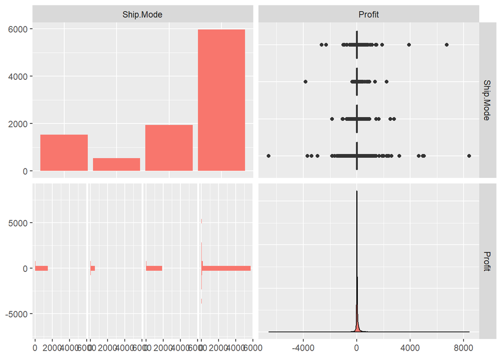

```r
ggpairs(retail, columns = c("Ship.Mode", "Profit"),ggplot2::aes(colour="species"))
```

## 4.5 Discount Effectiveness

**Just how effective is the discount promotion?**

```r
cor(retail$Discount, retail$Sales)
```

```
## [1] -0.02819012
```

```r
cor(retail$Discount,retail$Profit)
```

```
## [1] -0.2194875
```

**Correlation on Discount, Sales, Quantity, and Profits**

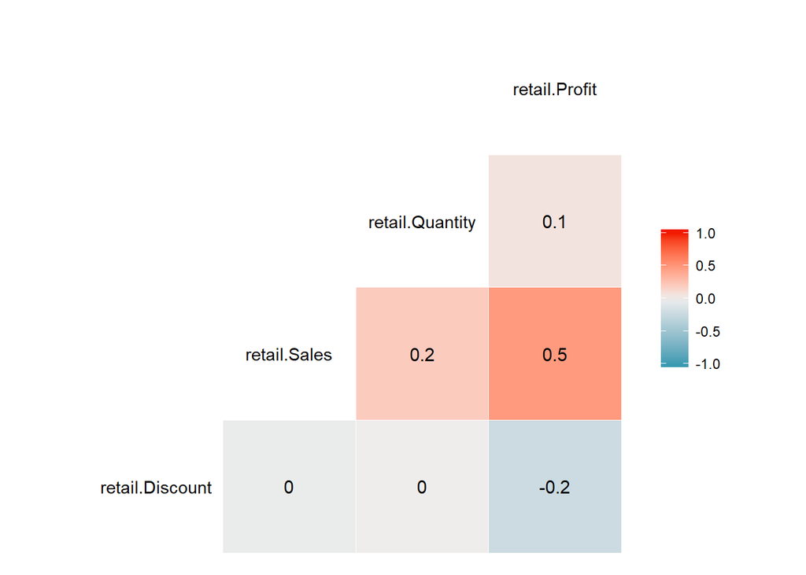

```r
correlation1 <- cbind.data.frame(retail$Discount, retail$Sales, retail$Quantity, retail$Profit)

ggcorr(data = correlation1, label = 1)
```

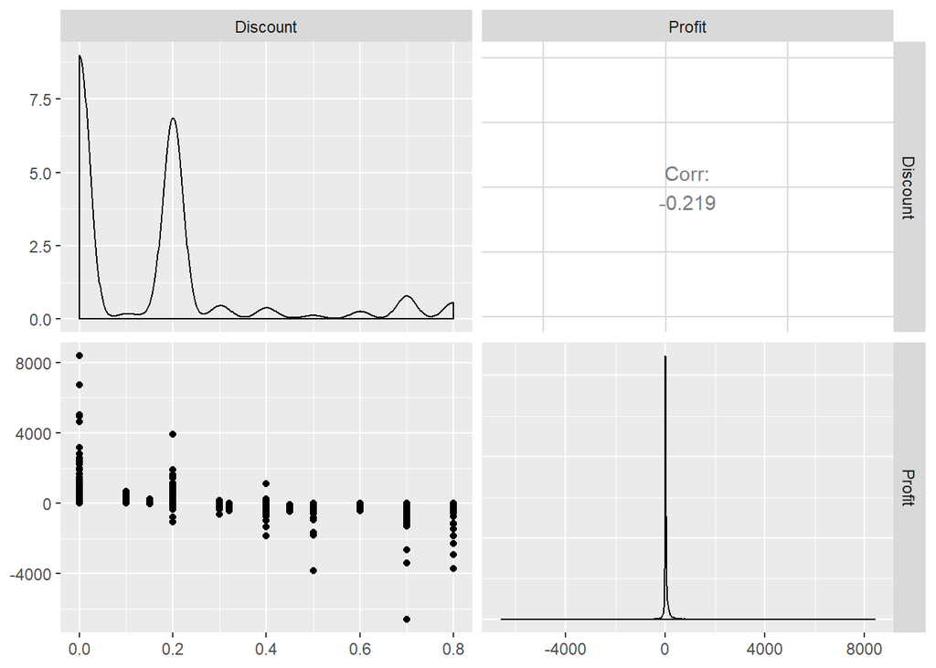

```r
ggpairs(retail, columns = c("Discount", "Profit"))
```

## 4.6 Sales and Profit Scatterplot

**Correlation on Sales and Profit**

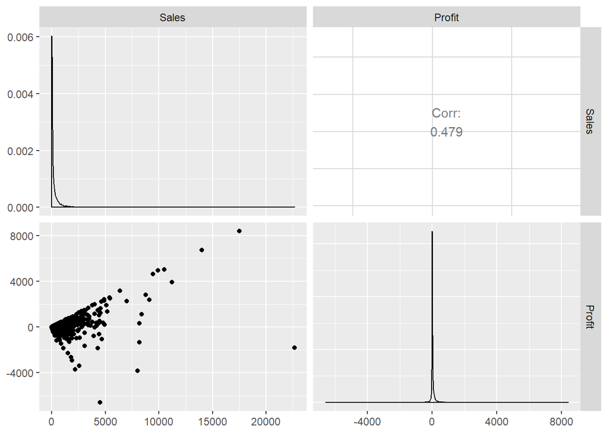

```r
ggpairs(retail, columns = c("Sales", "Profit"))
```

# 5 Data Conclusion

There’s a few things that we can conclude from the short analysis above : *The business should consider to stop selling Cubify CubeX 3D Printer Double Head Print* Based on correlation analysis between discount to sales as well as discount to profits, it doesn’t seem that the discount is effective in increasing sales. *After analyzing Sales and Profit scatter plot, it seemed that there’s a cluster in a low performing number, where sales and profit are close to 0. The company should revise their pricing strategy.* It seemed that the standard class shipping mode has the biggest profit, as well as the preferred shipping mode for a lot of the customers. *Consumer segment seemd to yield most profit and the most sale. This may be a good insight for the marketing or sales team.